# StarCraft II Replay Analysis

This project is a tutorial into basic data analysis using a StarCraft II replay dataset. We shall use a few of the most common tools to investigate the dataset such as PCA, k-mean clustering, and of course, linear regression to find information about the data and create a model to predict the league (skill) of a match. Let's begin.

## Background

In this project, data on SC2 replays is analyzed. SC2 is a PVP RTS that pits players against each other. The matches between players are based on MMR, which sorts players into various leagues (from Bronze 1 to GM). This project seeks to gain insight into the players' attributes and hopes to predict a player's league based on the game data.

## First Look

Pull the data from a csv(comma separated values) into a Pandas Dataframe and take a rough look at the data. Most of the features seem to follow some very clean distributions.

```python
import pandas as pd, numpy as np
df=pd.read_csv(r"starcraft.csv")
df.head()
```

|  | GameID | LeagueIndex | Age | HoursPerWeek | TotalHours | APM | SelectByHotkeys | AssignToHotkeys | UniqueHotkeys | MinimapAttacks | ... | NumberOfPACs | GapBetweenPACs | ActionLatency | ActionsInPAC | TotalMapExplored | WorkersMade | UniqueUnitsMade | ComplexUnitsMade | ComplexAbilityUsed | MaxTimeStamp |
| --- | --- | --- | --- | --- | --- | --- | --- | --- | --- | --- | --- | --- | --- | --- | --- | --- | --- | --- | --- | --- | --- |
| 0 | 52 | 5 | 27.0 | 10.0 | 3000.0 | 143.7180 | 0.003515 | 0.000220 | 0.000055 | 0.000110 | ... | 0.004849 | 32.6677 | 40.8673 | 4.7508 | 0.000220 | 0.001397 | 0.000047 | 0.0 | 0.000000 | 127448 |
| 1 | 55 | 5 | 23.0 | 10.0 | 5000.0 | 129.2322 | 0.003304 | 0.000259 | 0.000069 | 0.000294 | ... | 0.004307 | 32.9194 | 42.3454 | 4.8434 | 0.000381 | 0.001193 | 0.000087 | 0.0 | 0.000208 | 57812 |
| 2 | 56 | 4 | 30.0 | 10.0 | 200.0 | 69.9612 | 0.001101 | 0.000336 | 0.000042 | 0.000294 | ... | 0.002926 | 44.6475 | 75.3548 | 4.0430 | 0.000231 | 0.000745 | 0.000063 | 0.0 | 0.000189 | 95360 |
| 3 | 57 | 3 | 19.0 | 20.0 | 400.0 | 107.6016 | 0.001034 | 0.000213 | 0.000011 | 0.000053 | ... | 0.003783 | 29.2203 | 53.7352 | 4.9155 | 0.000202 | 0.000426 | 0.000075 | 0.0 | 0.000384 | 93852 |
| 4 | 58 | 3 | 32.0 | 10.0 | 500.0 | 122.8908 | 0.001136 | 0.000327 | 0.000039 | 0.000000 | ... | 0.002368 | 22.6885 | 62.0813 | 9.3740 | 0.000289 | 0.001174 | 0.000077 | 0.0 | 0.000019 | 51936 |

5 rows × 21 columns

#### First Look (Cont.)

We shall make a few graphs first to get a rough idea of how the data is distributed. Shown below is the minimalist code to generate some histograms for rough inspection (of course, we will be looking at this ourselves, do NOT show this to your boss on a presentation without polishing it first)

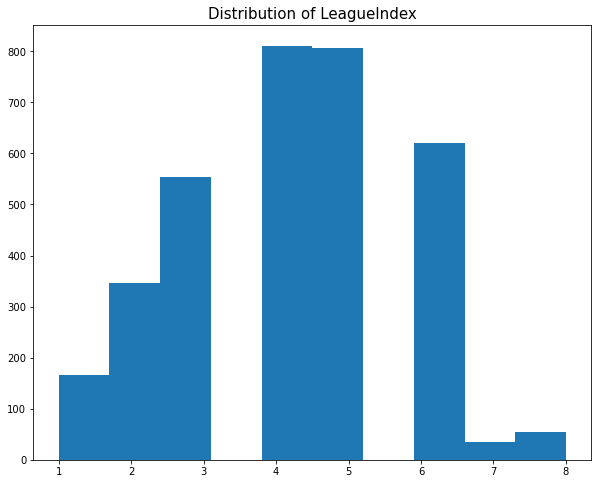

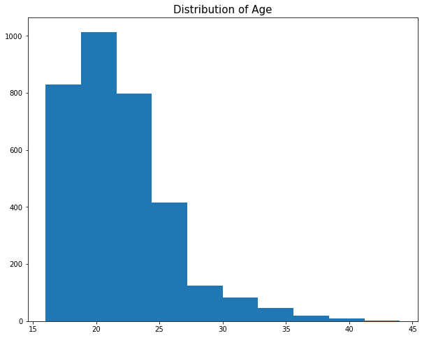

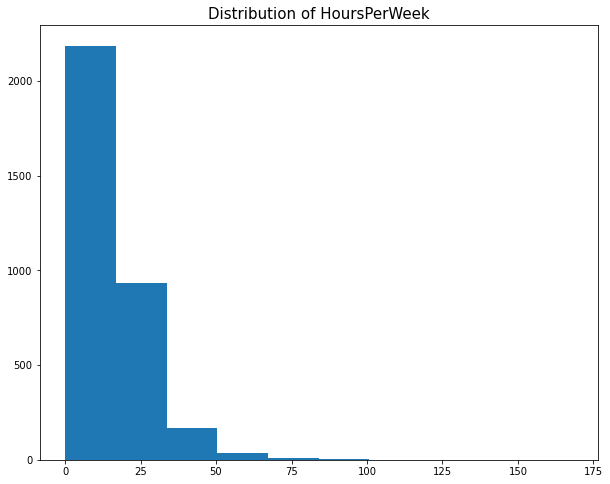

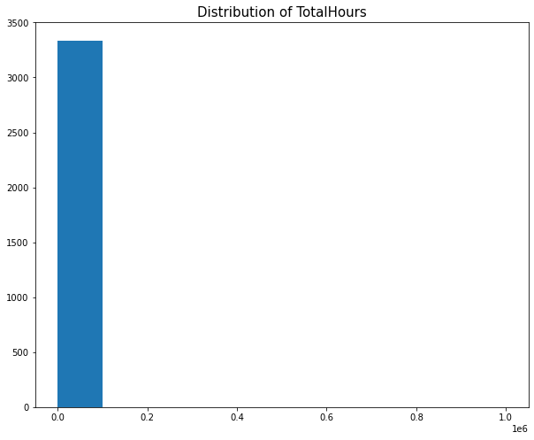

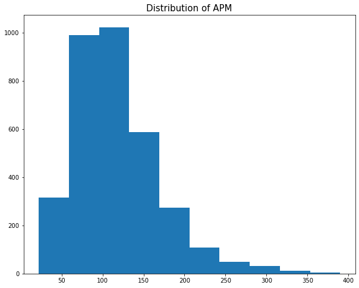

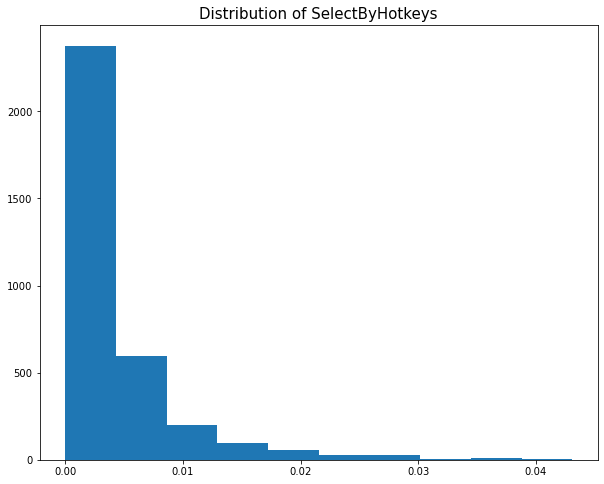

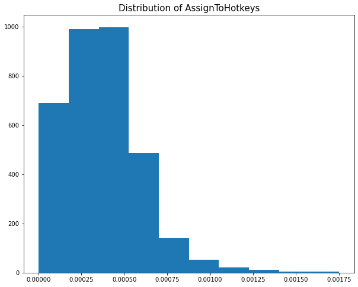

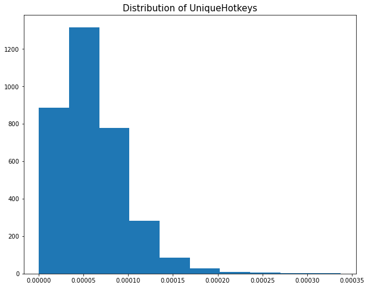

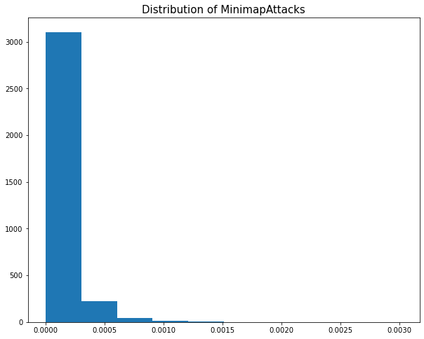

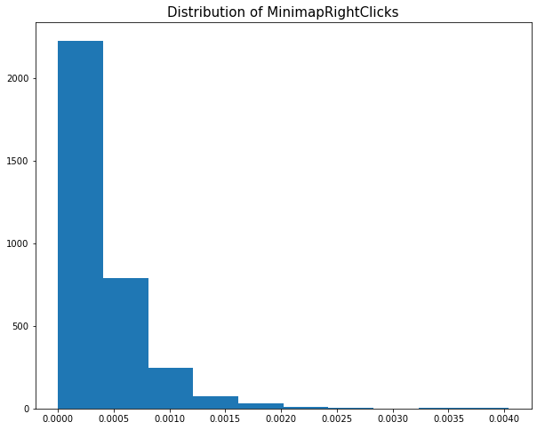

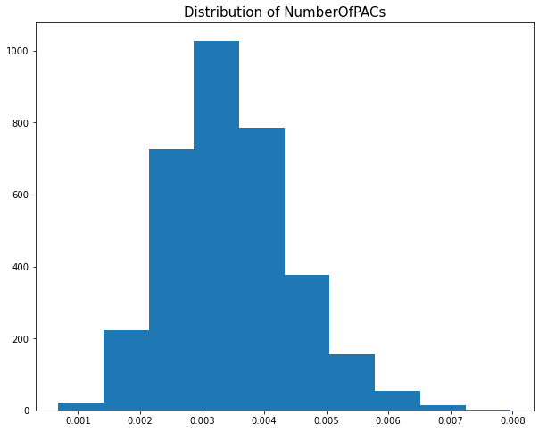

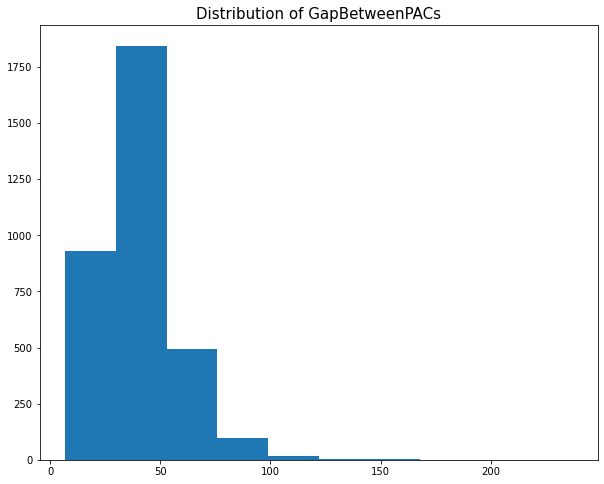

[8 more figures not shown]

```python
import matplotlib.pyplot as plt

df.drop(columns=['GameID'],inplace=True)
for colName in df.columns:
  fig,ax=plt.subplots(figsize=(10,8))
  ax.hist(df[colName])
  ax.set_title('Distribution of '+colName,fontsize=15)
```

### Outside Expertise

Judging from personal experience of the game, many of the aforementioned features are correlated with each other (for example, the assigning and using of hetkeys etc). Therefore, it would be prudent to check if these entries are really correlated. If so, PCA would be best to extract the most important information from the dataset.  
Even if you do not have previous knowledge of the data, PCA and correlation are always a nice option of feature engineering.

## Feature Engineering

#### Brief aside of PCA

PCA takes the original data and does a linear transformation (think stretching, reflecting and rotating) and turns it into a bunch of orthogonal components that explain the variance (basically eliminates most of the colinearity that would cause some problems with some algorithms down the road). Let's take a look at the correlation between the columns using .corr()

```python
df.corr()
```

|  | LeagueIndex | Age | HoursPerWeek | TotalHours | APM | SelectByHotkeys | AssignToHotkeys | UniqueHotkeys | MinimapAttacks | MinimapRightClicks | NumberOfPACs | GapBetweenPACs | ActionLatency | ActionsInPAC | TotalMapExplored | WorkersMade | UniqueUnitsMade | ComplexUnitsMade | ComplexAbilityUsed | MaxTimeStamp |
| --- | --- | --- | --- | --- | --- | --- | --- | --- | --- | --- | --- | --- | --- | --- | --- | --- | --- | --- | --- | --- |
| LeagueIndex | 1.000000 | -0.127825 | 0.217976 | 0.023884 | 0.662309 | 0.490599 | 0.531125 | 0.294980 | 0.312543 | 0.233231 | 0.612192 | -0.553246 | -0.673939 | 0.143121 | 0.232982 | 0.295643 | 0.111563 | 0.148833 | 0.145733 | -0.003790 |
| Age | -0.127825 | 1.000000 | -0.184508 | -0.016630 | -0.210559 | -0.131177 | -0.105609 | -0.004513 | 0.043388 | -0.019582 | -0.197282 | 0.112021 | 0.240348 | -0.045406 | -0.090594 | -0.092102 | -0.026603 | -0.080236 | -0.065737 | 0.042930 |
| HoursPerWeek | 0.217976 | -0.184508 | 1.000000 | 0.024306 | 0.246844 | 0.205785 | 0.158422 | 0.062190 | 0.084045 | 0.049424 | 0.174948 | -0.133770 | -0.188775 | 0.095091 | 0.061180 | 0.050623 | 0.031314 | 0.059325 | 0.074702 | 0.006740 |
| TotalHours | 0.023884 | -0.016630 | 0.024306 | 1.000000 | 0.072850 | 0.081830 | 0.042415 | 0.007953 | 0.000874 | 0.007662 | 0.039577 | -0.020644 | -0.035700 | 0.010704 | 0.026362 | 0.014828 | -0.000993 | -0.007154 | -0.006311 | -0.004556 |
| APM | 0.662309 | -0.210559 | 0.246844 | 0.072850 | 1.000000 | 0.840693 | 0.578416 | 0.320444 | 0.271021 | 0.322178 | 0.651237 | -0.575275 | -0.722402 | 0.383985 | 0.260569 | 0.349692 | 0.102066 | 0.136142 | 0.131588 | -0.020038 |
| SelectByHotkeys | 0.490599 | -0.131177 | 0.205785 | 0.081830 | 0.840693 | 1.000000 | 0.504526 | 0.327799 | 0.197158 | 0.143368 | 0.398505 | -0.304290 | -0.415388 | 0.163282 | 0.212857 | 0.141723 | 0.113452 | 0.044002 | 0.061038 | -0.085848 |
| AssignToHotkeys | 0.531125 | -0.105609 | 0.158422 | 0.042415 | 0.578416 | 0.504526 | 1.000000 | 0.340051 | 0.242197 | 0.193043 | 0.486729 | -0.396890 | -0.482190 | 0.093667 | 0.171185 | 0.183065 | 0.072920 | 0.144604 | 0.154410 | 0.004858 |
| UniqueHotkeys | 0.294980 | -0.004513 | 0.062190 | 0.007953 | 0.320444 | 0.327799 | 0.340051 | 1.000000 | 0.086231 | 0.079627 | 0.129747 | -0.213130 | -0.196359 | 0.146323 | 0.383204 | 0.127259 | 0.387962 | -0.117627 | -0.090686 | -0.423839 |
| MinimapAttacks | 0.312543 | 0.043388 | 0.084045 | 0.000874 | 0.271021 | 0.197158 | 0.242197 | 0.086231 | 1.000000 | 0.242268 | 0.177343 | -0.237631 | -0.199902 | 0.134803 | 0.033417 | 0.077622 | -0.036824 | 0.040244 | 0.044530 | 0.093223 |
| MinimapRightClicks | 0.233231 | -0.019582 | 0.049424 | 0.007662 | 0.322178 | 0.143368 | 0.193043 | 0.079627 | 0.242268 | 1.000000 | 0.176136 | -0.254466 | -0.230659 | 0.307512 | 0.112859 | 0.206594 | 0.063029 | 0.091607 | 0.090649 | 0.055443 |
| NumberOfPACs | 0.612192 | -0.197282 | 0.174948 | 0.039577 | 0.651237 | 0.398505 | 0.486729 | 0.129747 | 0.177343 | 0.176136 | 1.000000 | -0.506261 | -0.820334 | -0.232018 | 0.175364 | 0.277891 | -0.061927 | 0.181483 | 0.168293 | 0.214167 |
| GapBetweenPACs | -0.553246 | 0.112021 | -0.133770 | -0.020644 | -0.575275 | -0.304290 | -0.396890 | -0.213130 | -0.237631 | -0.254466 | -0.506261 | 1.000000 | 0.689402 | -0.311072 | -0.105821 | -0.235419 | -0.108015 | -0.074659 | -0.090565 | 0.055406 |
| ActionLatency | -0.673939 | 0.240348 | -0.188775 | -0.035700 | -0.722402 | -0.415388 | -0.482190 | -0.196359 | -0.199902 | -0.230659 | -0.820334 | 0.689402 | 1.000000 | -0.110224 | -0.235845 | -0.309175 | -0.044923 | -0.186405 | -0.184372 | -0.082962 |
| ActionsInPAC | 0.143121 | -0.045406 | 0.095091 | 0.010704 | 0.383985 | 0.163282 | 0.093667 | 0.146323 | 0.134803 | 0.307512 | -0.232018 | -0.311072 | -0.110224 | 1.000000 | 0.104756 | 0.251795 | 0.185555 | 0.052725 | 0.054536 | -0.194404 |
| TotalMapExplored | 0.232982 | -0.090594 | 0.061180 | 0.026362 | 0.260569 | 0.212857 | 0.171185 | 0.383204 | 0.033417 | 0.112859 | 0.175364 | -0.105821 | -0.235845 | 0.104756 | 1.000000 | 0.272495 | 0.471744 | -0.102323 | -0.084492 | -0.512077 |
| WorkersMade | 0.295643 | -0.092102 | 0.050623 | 0.014828 | 0.349692 | 0.141723 | 0.183065 | 0.127259 | 0.077622 | 0.206594 | 0.277891 | -0.235419 | -0.309175 | 0.251795 | 0.272495 | 1.000000 | 0.236420 | 0.203636 | 0.101942 | -0.134641 |
| UniqueUnitsMade | 0.111563 | -0.026603 | 0.031314 | -0.000993 | 0.102066 | 0.113452 | 0.072920 | 0.387962 | -0.036824 | 0.063029 | -0.061927 | -0.108015 | -0.044923 | 0.185555 | 0.471744 | 0.236420 | 1.000000 | -0.100346 | -0.101329 | -0.645804 |
| ComplexUnitsMade | 0.148833 | -0.080236 | 0.059325 | -0.007154 | 0.136142 | 0.044002 | 0.144604 | -0.117627 | 0.040244 | 0.091607 | 0.181483 | -0.074659 | -0.186405 | 0.052725 | -0.102323 | 0.203636 | -0.100346 | 1.000000 | 0.616680 | 0.314334 |
| ComplexAbilityUsed | 0.145733 | -0.065737 | 0.074702 | -0.006311 | 0.131588 | 0.061038 | 0.154410 | -0.090686 | 0.044530 | 0.090649 | 0.168293 | -0.090565 | -0.184372 | 0.054536 | -0.084492 | 0.101942 | -0.101329 | 0.616680 | 1.000000 | 0.265472 |
| MaxTimeStamp | -0.003790 | 0.042930 | 0.006740 | -0.004556 | -0.020038 | -0.085848 | 0.004858 | -0.423839 | 0.093223 | 0.055443 | 0.214167 | 0.055406 | -0.082962 | -0.194404 | -0.512077 | -0.134641 | -0.645804 | 0.314334 | 0.265472 | 1.000000 |

#### PCA

```python
df.dropna(inplace=True)

dfy=df['LeagueIndex'].copy()
# Normalize the dataframe, so that the pca does not give too skewed results
dfn=df/df.max()

dfx=dfn.drop(columns=['LeagueIndex'])
from sklearn.decomposition import PCA
pcaMod = PCA(n_components=0.95)
pcaMod.fit(dfx)
pcaMod.explained_variance_ratio_
```

```
array([0.2963108 , 0.16162127, 0.08913619, 0.06695432, 0.06404153,
       0.05223051, 0.04372919, 0.03837509, 0.03569727, 0.03489222,
       0.0281391 , 0.02422211, 0.01912753])
```

```python
pcadf=pd.DataFrame(pcaMod.components_,columns=dfn.drop(columns='LeagueIndex').columns)

X = pcaMod.transform(dfx)
pcadf.head()
```

|  | Age | HoursPerWeek | TotalHours | APM | SelectByHotkeys | AssignToHotkeys | UniqueHotkeys | MinimapAttacks | MinimapRightClicks | NumberOfPACs | GapBetweenPACs | ActionLatency | ActionsInPAC | TotalMapExplored | WorkersMade | UniqueUnitsMade | ComplexUnitsMade | ComplexAbilityUsed | MaxTimeStamp |
| --- | --- | --- | --- | --- | --- | --- | --- | --- | --- | --- | --- | --- | --- | --- | --- | --- | --- | --- | --- |
| 0 | -0.103775 | 0.079490 | 0.004445 | 0.480733 | 0.325685 | 0.380937 | 0.189048 | 0.051682 | 0.133260 | 0.387854 | -0.192887 | -0.378823 | 0.084783 | 0.168620 | 0.197407 | 0.114044 | 0.135456 | 0.082980 | -0.021511 |
| 1 | -0.028598 | 0.013508 | -0.000256 | 0.021534 | -0.051005 | 0.036573 | -0.362265 | 0.022869 | 0.005011 | 0.224818 | -0.016669 | -0.122049 | -0.104130 | -0.351208 | -0.064337 | -0.542089 | 0.377196 | 0.225064 | 0.414699 |
| 2 | 0.000123 | -0.018401 | -0.004506 | -0.101823 | -0.159509 | -0.081421 | -0.006874 | -0.008654 | 0.155823 | -0.230918 | 0.043340 | 0.112817 | 0.190806 | 0.099812 | 0.295202 | 0.329927 | 0.693640 | 0.368399 | -0.075157 |
| 3 | 0.215169 | 0.026336 | 0.003852 | 0.200490 | 0.398505 | 0.322140 | 0.186001 | 0.072693 | 0.140367 | -0.474008 | 0.050724 | 0.311021 | 0.327419 | -0.272669 | -0.212738 | -0.183489 | 0.031147 | 0.040531 | 0.059605 |
| 4 | -0.074485 | 0.020634 | 0.001524 | 0.255601 | 0.017159 | -0.475741 | -0.346607 | 0.055174 | 0.479908 | -0.102586 | -0.128404 | -0.082525 | 0.396299 | -0.039563 | 0.268307 | -0.083457 | -0.232207 | -0.149461 | 0.030387 |

Using the above PCA, one can label a few of the major components.

#### First Principal Component

The first principal component has the defining feature of high correlation between APM, Hotkey usage (Assign to Hotkeys and Select Hotkeys), Number of PAC (Perception Action Cycle, ie seeing something and reacting to it) and a strong negative correlation with Action Latency and Gap Between PAC. This supports the fact that the usage of hotkeys would make unit micromanagement easier and faster. Priliminary label of this component as unit micromanagement.

#### Second Principal Component

The most defining features of the second principal component is its correlation of Max Time Stamp (Game Length), ComplexUnitsMade (units that require long time/tech to produce and use) and negative correlation to Unique Units Made, Unique Hotkeys and Map Explored. This is known as "turtling" in the game (remain defensive and create a huge army of high tech units before finally bee-lining to opponent's base)

#### Third Principal Component

This corresponds to the player preference to spellcasting (usually relatively high tech) units vs normal units

#### Forth Principal Component

Corresponds roughly to aggressiveness: correlation of APM, Select by Hotkeys, Negative correlations of Unique Units Made, Workers Made and Map Explored (could be a timing attack?)

### K-mean

Playstyles tend to form clusters due to their similarity. Additionally different playstyles have drastically different stats associated with them (ie a Cannon-rush can have very low APM even when executed with high skill whereas with a bio playstyle, high APM is a must for high skill). Hence it would be wise to identify them before the actual model is develped. K means is employed to find these clusters (again with sklearn).  
The elbow method used to determine that 5 clusters would best suit the dataset. Although the "elbow" is not very pronounced.

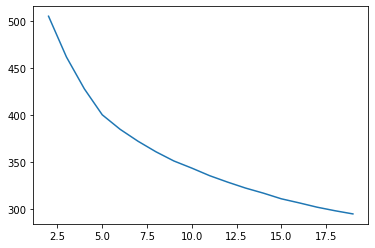

```python
from sklearn.cluster import KMeans
loss=[]
for a in range(2,20):
  km=KMeans(n_clusters=a).fit(dfx)
  loss.append(km.inertia_)
fig,ax=plt.subplots()
ax.plot(range(2,20),loss)
```

```python
km=KMeans(n_clusters=5).fit(X)
Xp=km.transform(X)
Xpp=np.concatenate([Xp,X],axis=1)
```

We shall now create the 2nd order interaction terms using sklearn's PolynomialFeatures.

```python
from sklearn.preprocessing import PolynomialFeatures
ply = PolynomialFeatures(2,interaction_only=True)
X=ply.fit_transform(Xpp)
```

## Linear Regression

We are now done wth feature engineering (hurray!) and can now build the model itself. We will now perform a linear regression on the characteristics of the matches and using the league as the target. Because leagues are a stand in for skill (and implies order), the use of linear regression is somewhat appropriate however, we do need to round before computing accuracy  
Again we shall use sklearn.

### Train Test Split

Hold your horse, we are not ready to train the model on all the data. We want ot be sure that the model works on all of the data, not just the data it trained on (the technical term is overfitting), we will split off 10% of the data that the model is NOT allowed to see, and train with the remaining 90%.  
The 10% is called the test-set, and we will later use it to see how good our model is after training.

```python
from sklearn.model_selection import train_test_split
y=dfy.values.reshape(-1,1)
x_train,x_test,y_train,y_test=train_test_split(X,y,test_size=0.1)
```

```python
# The actual linear regression itself
from sklearn.linear_model import LinearRegression
linreg=LinearRegression()
linreg.fit(x_train,y_train)
```

```
LinearRegression()
```

## Model Evaluation

Let's see how well our model performs. We use the predict function on the training and test sets to get the predicted League index of the players (of course we also need to round it). We will be using the root mean square error to check the accuracy.

```python
# Training loss
y_pred=np.rint(linreg.predict(x_train))
loss=y_pred-y_train
import math
sqloss=loss**2
math.sqrt(sqloss.mean())
```

```
0.9753963993264011
```

```python
# Testing Loss
y_pred=np.rint(linreg.predict(x_test))
loss=y_pred-y_test
sqloss=loss**2
math.sqrt(sqloss.mean())
```

```
1.1133377556176887
```

## Bonus Cool Stuff

Remember the principal components of that we have? We can use them to label matches in Radar plots for some really cool visuals (you might have seen them in esports). So this is something that you might want to show to your boss/viewers to intrigue them.  
We first grab the PCA-transformed data and ensure that the minimum of each column is 0 (so our graph does not go below 0).

```python
Xp=pcaMod.transform(dfx)
Xp=Xp-Xp.min(axis=0)
```

We will now take advantage of the polar plot of matplotlib. We want to graph the first 5 principal components, which are Micro, Turtle, Tech, Aggresiveness and Macro.

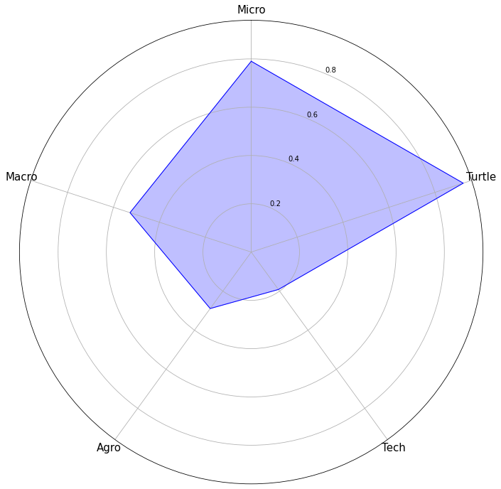

```python
plt.rc('figure', figsize=(12, 12))
ax=plt.subplot(1,1,1,polar=True)

# Polar angles
angles = [n / 5.0 * 2 * 3.1415926 for n in range(5)]
ax.set_theta_offset(3.1415 / 2)
ax.set_theta_direction(-1)


# Create the labels
compo = ['Micro','Turtle','Tech','Agro','Macro']
plt.xticks(angles, compo, size=15)
ax.tick_params(axis='x')

angles=np.append(angles,angles[0])
values = Xp[0,:5]
values=np.append(values, values[0])
ax.plot(angles, values, color = "blue", linewidth=1, linestyle='solid')
ax.fill(angles, values, color = "blue", alpha = 0.25)
```

The first match replay is a very turtle-ly player who has somewhat good micro and medium micro. Not very aggressive nor interested in tech.

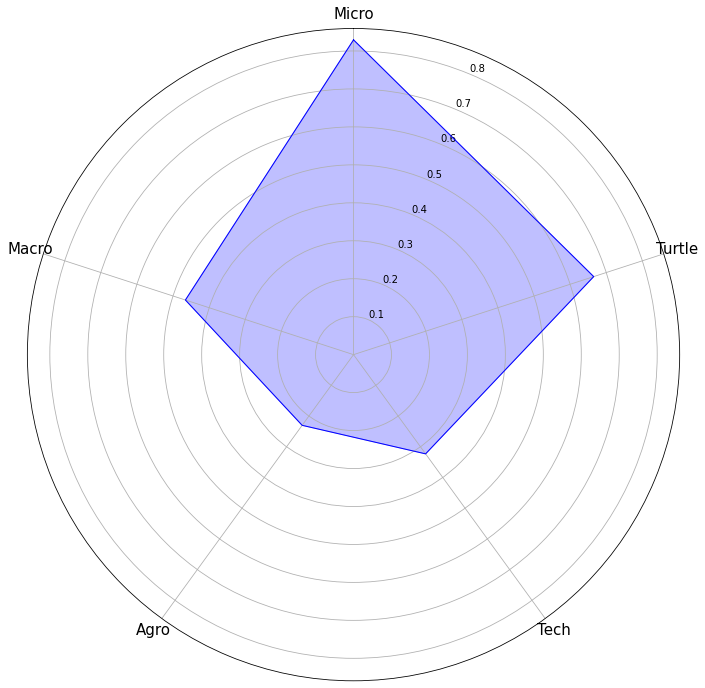

```python
plt.rc('figure', figsize=(12, 12))
ax=plt.subplot(1,1,1,polar=True)

# Polar angles
angles = [n / 5.0 * 2 * 3.1415926 for n in range(5)]
ax.set_theta_offset(3.1415 / 2)
ax.set_theta_direction(-1)


# Create the labels
compo = ['Micro','Turtle','Tech','Agro','Macro']
plt.xticks(angles, compo, size=15)
ax.tick_params(axis='x')
angles += angles[:1]

values = Xp[1,:5]
values=np.append(values, values[0])
ax.plot(angles, values, color = "blue", linewidth=1, linestyle='solid')
ax.fill(angles, values, color = "blue", alpha = 0.25)
```

So, the second matchup is not very aggressive, quite micro and turtle heavy. Additional matches replays can be generated the same way with different rows of the numpy array.